# HW2

Artur Sak

September 13, 2016

# PART 1. Family Data

Load the data from the Web into your R session with the following command:

```r
load(url("http://courseweb.lis.illinois.edu/~jguo24/family.rda"))
```

In the following exercises try to write your code to be as general as possible so that it could still work if the family had 27 members in it or if the variables were in a different order in the data frame.

Q1. (2 pts.) The NHANES survey (the source of the family data) used different cut-off values for men and women when classifying them as over weight. Suppose that a man is classified as obese if his bmi exceeds 26 and a woman is classified as obese if her bmi exceeds 25.

```r
objects()
```

```
## [1] "fage"       "family"     "fbmi"       "fdesiredWt" "fgender"
## [6] "fheight"    "fnames"     "foverWt"    "fweight"
```

Write a logical expression to create a logical vector, called OW_NHANES, that is TRUE if a member of family is obese and FALSE otherwise

```r
OW_NHANES = (family$gender == "m" & family$bmi > 26) | (family$gender == "f" & family$bmi > 25)
print(OW_NHANES)
```

```
##  [1] FALSE FALSE FALSE FALSE FALSE  TRUE  TRUE FALSE  TRUE  TRUE  TRUE
## [12] FALSE FALSE FALSE
```

Q2. (4 pts.) Here is an alternative way to create the same vector that introduces some useful functions and ideas

We will begin by creating a numeric vector called OW_limit that is 26 for each male in the family and 25 for each female in the family.

To do this, first create a vector of length 2 called OWval whose first element is 26 and second element is 25.

```r
OWval = c(26, 25)
```

Create the OW_limit vector by subsetting OWval by position, where the positions are the numeric values in the gender variable (i.e. use as.numeric to coerce the factor vector to a numeric vector)

```r
OW_limit = OWval[as.numeric(family$gender)]
```

Finally, use OW_limit and bmi to create the desired logical vector, and call it OW_NHANES2.

```r
OW_NHANES2 = (family$bmi > OW_limit)
print(OW_NHANES2)
```

```
##  [1] FALSE FALSE FALSE FALSE FALSE  TRUE  TRUE FALSE  TRUE  TRUE  TRUE
## [12] FALSE FALSE FALSE
```

Q3. (2 pts.) Use the vector OW_limit and each person’s height to find the weight that they would have if their bmi was right at the limit (26 for men and 25 for women). Call this weight OW_weight

To do this, start with the formula: bmi = (weight/2.2) / (2.54/100 * height)^2 and find re-express it in terms of weight.

```r
OW_weight = (OW_limit * (2.54/100 * family$height)^2) * 2.2
print(OW_weight)
```

```
##  [1] 180.8254 145.3416 196.6569 165.6582 145.3416 164.0771 170.6402
##  [8] 149.9191 170.6402 186.0288 159.2868 160.7501 160.7501 136.3997
```

Make a plot of the weight at which they would be over weight against actual weight

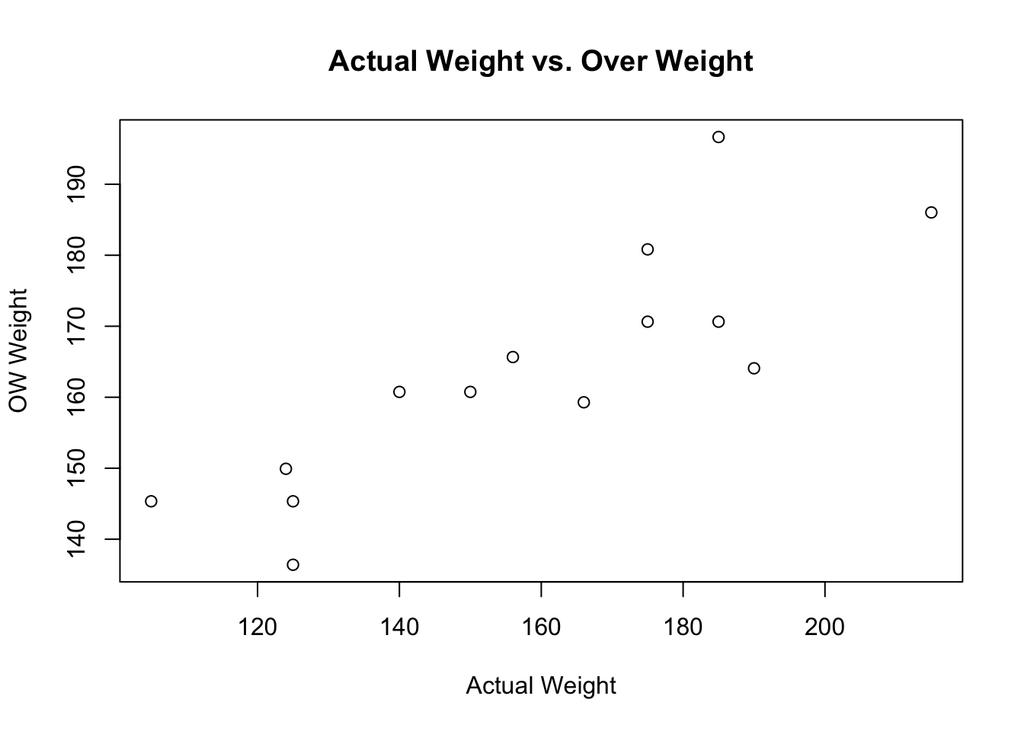

```r
plot(family$weight,OW_weight, main="Actual Weight vs. Over Weight", xlab="Actual Weight", ylab="OW Weight")
```

# PART 2. Baseball data

Load the data into R. In order to access this data set we will install the relevant package and use the following code to do so:

```r
install.packages("vcd", repos='http://ftp.ussg.iu.edu/CRAN/')
```

```r
library(vcd)
attach(Baseball)
```

This means that the dataset Baseball was in the vcd package.

Q4. (4 pts.) How many variables are in the dataset Baseball?

```r
print(length(Baseball))
```

```
## [1] 25
```

**25 variables**

How many observations are in Baseball?

```r
print(dim(Baseball))
```

```
## [1] 322  25
```

**322 observations**

For a more DETAILED description of ALL of the variables is this data set, visit: https://vincentarelbundock.github.io/Rdatasets/doc/vcd/Baseball.html

Run the summary function and answer the following questions: For the variable team87, which state had the most baseball players in the dataset?

```r
print(summary(Baseball))
```

```
##     name1              name2              atbat86          hits86
##  Length:322         Length:322         Min.   : 16.0   Min.   :  1
##  Class :character   Class :character   1st Qu.:255.2   1st Qu.: 64
##  Mode  :character   Mode  :character   Median :379.5   Median : 96
##                                        Mean   :380.9   Mean   :101
##                                        3rd Qu.:512.0   3rd Qu.:137
##                                        Max.   :687.0   Max.   :238
##
##     homer86          runs86           rbi86           walks86
##  Min.   : 0.00   Min.   :  0.00   Min.   :  0.00   Min.   :  0.00
##  1st Qu.: 4.00   1st Qu.: 30.25   1st Qu.: 28.00   1st Qu.: 22.00
##  Median : 8.00   Median : 48.00   Median : 44.00   Median : 35.00
##  Mean   :10.77   Mean   : 50.91   Mean   : 48.03   Mean   : 38.74
##  3rd Qu.:16.00   3rd Qu.: 69.00   3rd Qu.: 64.75   3rd Qu.: 53.00
##  Max.   :40.00   Max.   :130.00   Max.   :121.00   Max.   :105.00
##
##      years            atbat              hits           homeruns
##  Min.   : 1.000   Min.   :   19.0   Min.   :   4.0   Min.   :  0.00
##  1st Qu.: 4.000   1st Qu.:  816.8   1st Qu.: 209.0   1st Qu.: 14.00
##  Median : 6.000   Median : 1928.0   Median : 508.0   Median : 37.50
##  Mean   : 7.444   Mean   : 2648.7   Mean   : 717.6   Mean   : 69.49
##  3rd Qu.:11.000   3rd Qu.: 3924.2   3rd Qu.:1059.2   3rd Qu.: 90.00
##  Max.   :24.000   Max.   :14053.0   Max.   :4256.0   Max.   :548.00
##
##       runs             rbi              walks         league86 div86
##  Min.   :   1.0   Min.   :   0.00   Min.   :   0.00   A:175    E:157
##  1st Qu.: 100.2   1st Qu.:  88.75   1st Qu.:  67.25   N:147    W:165
##  Median : 247.0   Median : 220.50   Median : 170.50
##  Mean   : 358.8   Mean   : 330.12   Mean   : 260.24
##  3rd Qu.: 526.2   3rd Qu.: 426.25   3rd Qu.: 339.25
##  Max.   :2165.0   Max.   :1659.00   Max.   :1566.00
##
##      team86       posit86        outs86          assist86
##  Chi    : 24   C      : 40   Min.   :   0.0   Min.   :  0.0
##  NY     : 24   3B     : 32   1st Qu.: 109.2   1st Qu.:  7.0
##  Bal    : 15   1B     : 31   Median : 212.0   Median : 39.5
##  KC     : 14   2B     : 31   Mean   : 288.9   Mean   :106.9
##  LA     : 14   OF     : 30   3rd Qu.: 325.0   3rd Qu.:166.0
##  Mil    : 14   SS     : 30   Max.   :1378.0   Max.   :492.0
##  (Other):217   (Other):128
##     error86          sal87        league87     team87
##  Min.   : 0.00   Min.   :  67.5   A:176    NY     : 24
##  1st Qu.: 3.00   1st Qu.: 190.0   N:146    Chi    : 22
##  Median : 6.00   Median : 425.0            Pit    : 16
##  Mean   : 8.04   Mean   : 535.9            Bal    : 15
##  3rd Qu.:11.00   3rd Qu.: 750.0            SF     : 15
##  Max.   :32.00   Max.   :2460.0            KC     : 14
##                  NA's   :59                (Other):216
```

**State with Most Baseball Players:** New York

Make an observation about the variable, sal87, which is the yearly salary of the selected baseball players in the dataset.

- The distribution of salaries is skewed to the right because the median is less than the mean.

Who is the highest paid player in the data set?

```r
print(Baseball[!is.na(sal87) & sal87 == max(sal87[!is.na(sal87)]), c("name1", "name2")])
```

OR

```r
print(Baseball[which.max(sal87), c("name1", "name2")])
```

```
##     name1  name2
## 100 Eddie Murray
```

**Highest Paid Player:** Eddie Murray

Q5. (2 pts.) Now, we only want to use the baseball players in the National League. This information is found through the variable, league86. The letter N indicates that the player is in the National League. The letter A indicates that the player is in the American League. Subset the new data frame so that all of the baseball players are in the National League, and only keep the following variables: name1, name2, years, hits86, homer86, homeruns,rbi, and sal87. To clarify, the variable, homer86 are the homeruns in that the player hit in ’86, and the variable homeruns are career homeruns for each player. Call the new data Baseball1

```r
Baseball1 = Baseball[league86 == "N", c("name1", "name2", "years", "hits86", "homer86", "homeruns", "rbi", "sal87")]
```

Q6. (2 pts.) We want to remove unusually large values in order to further subset the data. Use the quantile function to determine the 99% of variable sal87 (the salaries of the players in ’87). Then remove those baseball players that are above the 99th percentile. Call this new dataset Baseball1 as well.

```r
Baseball1 = Baseball1[!is.na(Baseball1$sal87) & Baseball1$sal87 < quantile(Baseball1$sal87, probs=0.99, na.rm = TRUE),]
```

Q7. (2 pts.) Create a new vector called hitsperhome. Divide hits86 by homer86, and this will create our new vector. Now add this new variable to the data frame.

```r
hitsperhome = Baseball1$hits86 / Baseball1$homer86
Baseball1$hitsperhome = hitsperhome
```

Q8. (2 pts.) Create a vector called hr15, this will be the number of homeruns hit in the year 1986 (NOT total) so use the variable, homer86, if this number is greater than 15, it is set to 15. So if a player has 15 or more homeruns in that year, then hr15 will be 15, otherwise it will be the actual number of homeruns.

```r
hr15 = sapply(Baseball1$homer86, function(x) ifelse(x>15,15,x))
print(hr15)
```

```
##   [1]  1  7  4 15 10  6 13 15  7  6 10  6 10 15  4  5  8 15 15  9 13  7  6
##  [24]  6  2 15  4 15  1  3 15  7 13 15 15  2 15 15 11 15  4 15 15 15  5  4
##  [47] 10 14  9  6  5  5 15 15  5  4 13  7 10  3 15  6 13 12  4  5 15 15 12
##  [70]  0  8  9 15  8  7  2 12  8  3 15  5  6  8  9 15  0  9  0  8  1 11  8
##  [93]  7 13  8  5  3 14 15 15 15  0  6  4  8  1  1  3  3  4 15  2  1  2 14
## [116] 10  5  0 15  1 11  7
```

Q9. (2 pts.) Find out if there is a significant association between homeruns hit in 1986, variable homer86, and the salary of the players on opening day in 1987, variable sal87 (which is USD 1000). Answer this using several functions, including the plot function. Make 3 observations below.

```r
reg = lm(Baseball1$sal87~Baseball1$homer86)
print(summary(reg))
```

```
##
## Call:
## lm(formula = Baseball1$sal87 ~ Baseball1$homer86)
##
## Residuals:
##     Min      1Q  Median      3Q     Max
## -805.48 -251.56  -43.98  216.38 1215.87
##
## Coefficients:
##                   Estimate Std. Error t value Pr(>|t|)
## (Intercept)        268.991     53.647   5.014 1.86e-06 ***
## Baseball1$homer86   24.242      4.424   5.479 2.39e-07 ***
## ---
## Signif. codes:  0 '***' 0.001 '**' 0.01 '*' 0.05 '.' 0.1 ' ' 1
##
## Residual standard error: 354.7 on 120 degrees of freedom
## Multiple R-squared:  0.2001, Adjusted R-squared:  0.1935
## F-statistic: 30.02 on 1 and 120 DF,  p-value: 2.392e-07
```

```r
print(cor(Baseball1$homer86, Baseball1$sal87))
```

```
## [1] 0.4473575
```

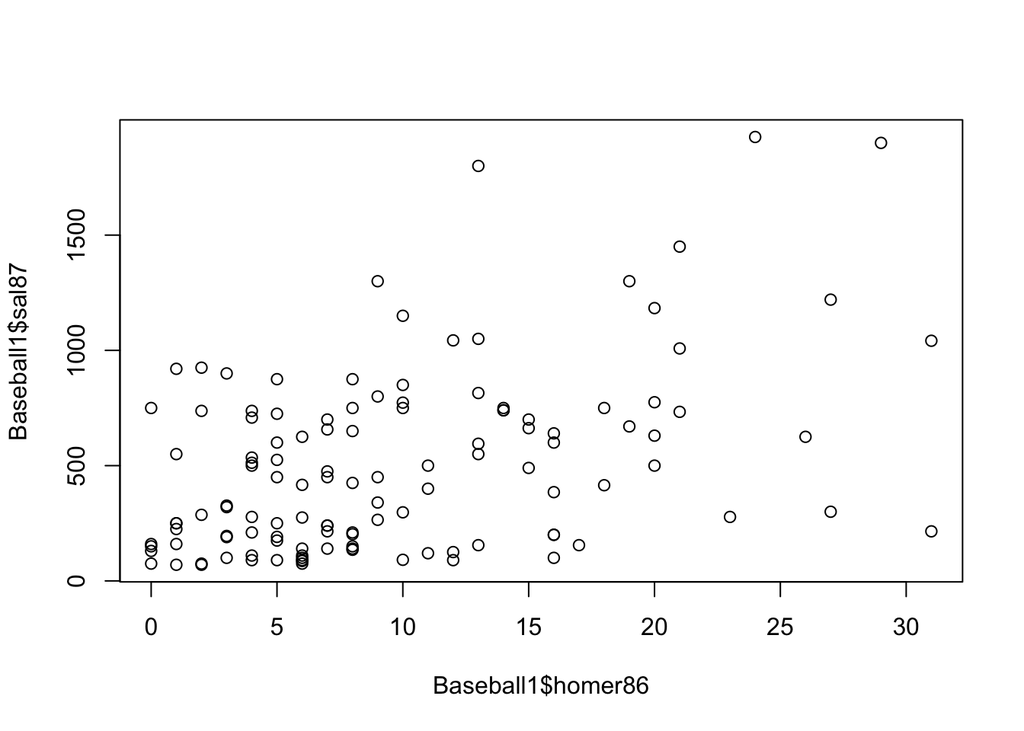

```r
plot(Baseball1$homer86,Baseball1$sal87)
```

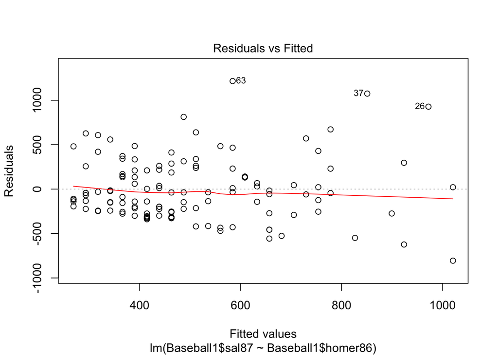

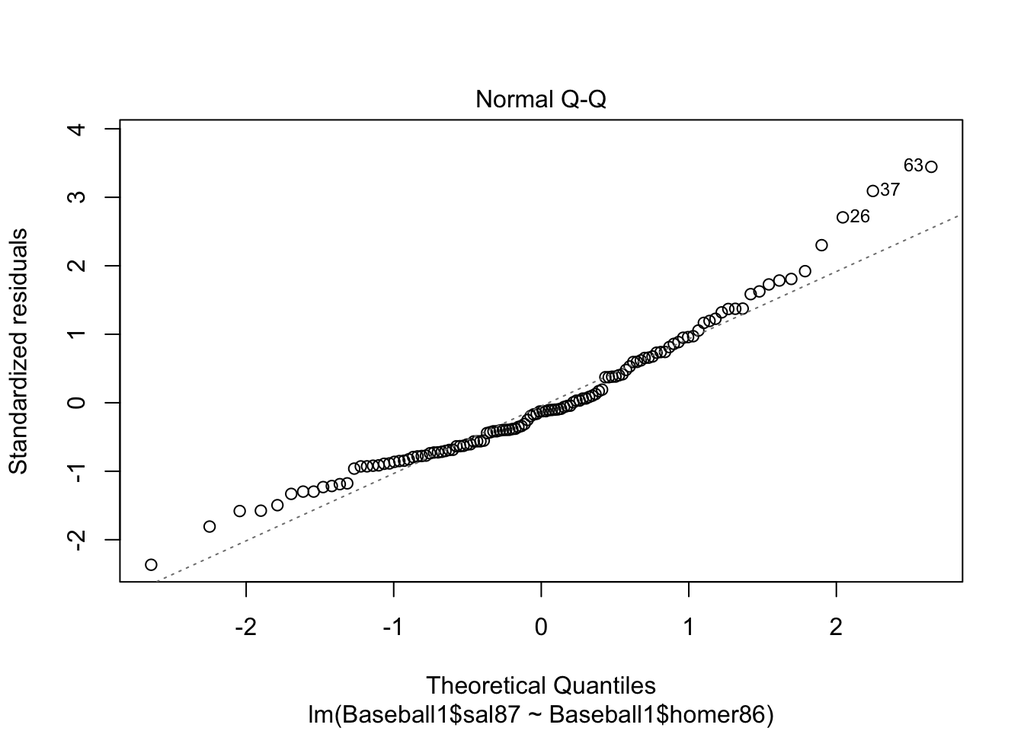

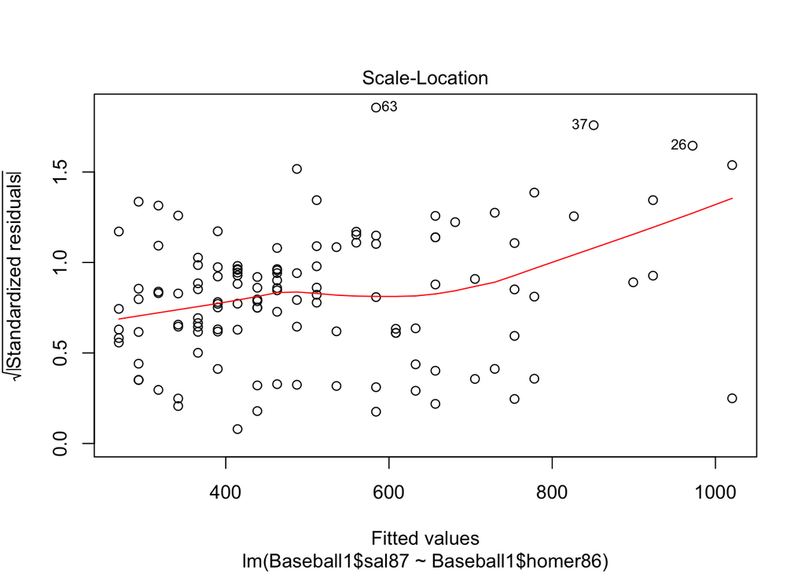

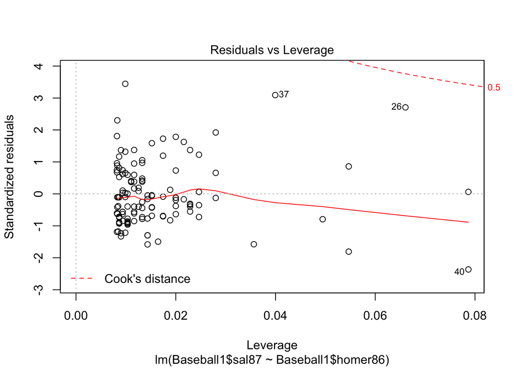

```r
plot(reg)
```